# Kaggle Contest Notes

Connor Lennon | University of Oregon

EC 524

## Kaggle Competition

Welcome to the term! Let’s get stuck-in. We did MOST of this work in class, but I wanted a document for you guys to reference. I’m going to do WAY more work than you need to, but just in case I wanted to show you what to do.

If you are looking for information about your assignment or the course in general, I advise you go check out [Ed Rubins Github page](https://github.com/edrubin/EC524W20) and also look at the specific assignment page where your questions are [here](https://github.com/edrubin/EC524W20/tree/master/projects/kaggle-house-prices)

Step 1 is to get the data. That’s going to come from [kaggle](https://www.kaggle.com/c/house-prices-advanced-regression-techniques/data). You’ll need an account, you’ll need to register for this competition, and then you’ll need to download the data (click download all, in the area below)

[figure not shown]

Here’s a picture

Let’s check out what data we get. We could do this in R, but let’s start with the *data_descriptions* file. This will explain what all of these variables mean, and is a great resource to trying to run a prediction.

Let’s start by analyzing what kind of missing data we have… Now we need R. And we need packages. You guys have done this, but I put some inline comments in to help out a bit.

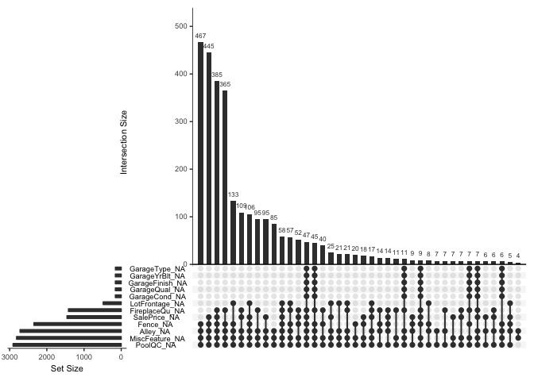

```r
#load training data, add 'test column', transform prices to logged SalePrices

#In general, we will want to use 'pacman' to load our packages. It's really nice,
#and streamlines a ton of work for us.
#install.packages('pacman') #if you haven't used pacman before, you need to install it
library(pacman) #add pacman to your workspace
p_load(tidyverse, ggplot2, naniar, tidyimpute, tidymodels, magrittr)
#loading packages with pacman is super easy.
#Just use p_load(package_name1, package_name2) etc.

#now you need to load your data. I just left it in my downloads folder,
#but you can get your data wherever you decide to leave it.
train_df <- read_csv('/Users/connor/Downloads/house-prices-advanced-regression-techniques/train.csv')
train_df <-train_df %>% mutate(test = 0, SalePrice = log(SalePrice))

#load test data, add 'test' column, add empty SalePrice col.
test_df <- read_csv('/Users/connor/Downloads/house-prices-advanced-regression-techniques/test.csv')
test_df <- test_df %>% mutate(test = 1, SalePrice = NaN)
#we need to create an empty sale-price column so the dataframes match in size.

#glue them together-
fulldf <- rbind(train_df, test_df)

#We can use the naniar package to visualize missingness in our
#data in a super intuitive way, with the gg_miss_upset() function.
missing_vals <- fulldf %>% select_if(~ any(is.na(.)))
missing_vals %>% gg_miss_upset(nsets = 12)
```

Now, we need to replace some of our values. Let’s do this the hard way as a warm-up, and then move on.

```r
fulldf$PoolQC <- fulldf$PoolQC %>% replace_na("None")
fulldf$MiscFeature <- fulldf$MiscFeature %>% replace_na("None")
fulldf$Alley <- fulldf$Alley %>% replace_na("None")
fulldf$Fence <- fulldf$Fence %>% replace_na("None")
fulldf$FireplaceQu <- fulldf$FireplaceQu %>% replace_na("None")

#ok.. Whatr about lot frontage? We have missing values, but maybe we can use information about
#nearby houses to "impute" what we would expect for a similar house. Let's do that.
fulldf <-fulldf %>%
  group_by(Neighborhood) %>%
  mutate(LotFrontage=ifelse(is.na(LotFrontage),median(LotFrontage,na.rm=TRUE),LotFrontage)) %>%
  ungroup()
# I would like to add a time trend. Why? Because I feel like it. Here's how I thought to do this.

#can you come up with a different way?

#the %<>% assigns the dataframe you create to the name of the dataframe you started with, that is, %>% passes your dataframe into a fcn, %<>% will change the dataframe entirely.

fulldf %<>% mutate(time = 12*YrSold + MoSold) %>% mutate(time = time - min(time, na.rm = TRUE))
```

Now let’s speed things up for ourselves -

```r
#These variables are really factors, not numeric. So let's change them.
#Factors will treat 1, 2, 3 etc. as individual dummy variables.
factcols = c('MSSubClass', 'OverallCond', 'YrSold',
             'MoSold')
fulldf[factcols] <- lapply(fulldf[factcols], factor)

#The following columns' missing observations are likely to be
#replacable with 0 because 'NA' really means no basement or no garage
bsmtcols = c('BsmtFinSF1', 'BsmtFinSF2', 'BsmtUnfSF', 'TotalBsmtSF',
             'BsmtFullBath', 'BsmtHalfBath', 'GarageYrBlt', 'GarageArea', 'GarageCars', 'MasVnrArea')

#this will replace all NA values with 0.
fulldf[bsmtcols] %<>% replace(is.na(.), 0)


#for the same reasons as above, we can add some clarity by replacing the following observations with 0
nonecols = c('GarageType', 'GarageFinish', 'GarageQual', 'GarageCond', 'BsmtQual',
             'BsmtCond', 'BsmtExposure', 'BsmtFinType1', 'BsmtFinType2', 'MasVnrType', 'MSSubClass')

fulldf[nonecols] %<>% replace(is.na(.), "None")

#These are more difficult. Because we don't know much about the
#following variables, we can replace these NAs with the modal observed outcome.
#You should think carefully about doing this, what are you assuming?

modecols = c('MSZoning', 'Electrical','KitchenQual', 'Exterior1st', 'Exterior2nd','SaleType')
fulldf[,c(modecols)] %<>% impute_most_freq(modecols)

#the documentation for 'Functional' says NA == "Typical" so we can replace with 'Typ'
fulldf$Functional %<>% replace_na("Typ")

#Let's 'engineer' a useful variable. Here, we can build a Total square footage variable to use for prediction.
fulldf$TotalSF <- fulldf$TotalBsmtSF + fulldf$`1stFlrSF` + fulldf$`2ndFlrSF`
```

## Making Predictions

Now we need to make our predictions

```r
#Now, we need to break our datasets back up again.
#Also, those variables that start with a number are going to give R headaches,
#so let's change their names to something we can read but so can the computer.

traindf <- subset(fulldf, test ==0)

#renaming columns
colnames(traindf)[which(names(traindf) %in% c('1stFlrSF', '2ndFlrSF', '3SsnPorch'))] <- c('FirstFlrSF', 'SecondFlrSF', 'ThrSsnPorch')
#drop test (it's meaningless, and utilities because there is zero variation in it)
traindf %<>% select(-c('test','Utilities'))

#now, we repeat above steps for test data.
testdf <- subset(fulldf, test ==1)
testdf %<>% select(-c('test', 'Utilities'))
colnames(testdf)[which(names(testdf) %in% c('1stFlrSF', '2ndFlrSF', '3SsnPorch'))] <- c('FirstFlrSF', 'SecondFlrSF', 'ThrSsnPorch')

#Now, you have to come up with a good model for prediction! How should you do that? Think a bit about your approach here.


#I am going to use Ed's model, which is a 'Random Forest.' You'll learn about these later,
#but for now you can ignore this. Just come up with a model using the lm() function and forecast away!

#A nice function to find variables not in a group
`%nin%` = Negate(`%in%`)

 model_trained = rand_forest(mode = "regression", mtry = 24, trees = 10000) %>%
    set_engine("ranger", seed = 12345, num.threads = 10, verbose = TRUE) %>%
    fit_xy(
      y = traindf$SalePrice,
      x = traindf[which(names(traindf) %nin% c('ID', 'SalePrice'))]
    )

#assign predictions to a new variable
new_predictions = predict(
    model_trained,
    new_data = testdf
  )

#Maybe, however, you are interested in seeing how your model performs 'out of sample.' Let's do that.

#we'll start by splitting the data in half. We can use the
#sample function this way: sample(dataframe, number of rows to sample)

#sampling vector
s <- sample(nrow(traindf), length(traindf)/2)
minitrain = traindf[s,]
minitest = traindf[-s,]

model_minitrain = rand_forest(mode = "regression", mtry = 24, trees = 10000) %>%
    set_engine("ranger", seed = 12345, num.threads = 10, verbose = TRUE) %>%
    fit_xy(
      y = minitrain$SalePrice,
      x = minitrain[which(names(minitrain) %nin% c('ID', 'SalePrice'))]
    )

#now predict on our excluded subsample. For you, you'd use predict(my_reg, minitest)
mini_predictions = predict(
    model_minitrain,
    new_data = minitest
  )
mini_predictions
```

```
## # A tibble: 1,419 x 1
##    .pred
##    <dbl>
##  1  12.3
##  2  12.0
##  3  12.3
##  4  12.0
##  5  12.6
##  6  12.0
##  7  12.6
##  8  12.3
##  9  11.8
## 10  11.8
## # … with 1,409 more rows
```

```r
#then, we may want to look at MSE. We will compare the differences from our test data and our predictions

err = exp(mini_predictions) - exp(minitest$SalePrice)
errsq = err^2
summary(errsq)
```

```
##      .pred
##  Min.   :0.000e+00
##  1st Qu.:6.273e+07
##  Median :2.939e+08
##  Mean   :1.454e+09
##  3rd Qu.:1.052e+09
##  Max.   :1.521e+11
```

```r
#it's not great! How do we get the mean?

#take the mean of the sum... and you have your MSE for housing data
lapply(errsq, mean, na.rm = TRUE)
```

```
## $.pred
## [1] 1454200617
```

```r
#now, you need to build a dataframe to hold onto the 'ID' variable and then another one.
#The random forest is overwriting my column name but
#I don't like that so I'm going to overwrite the column names.
submission_test = data.frame(
  Id = testdf$Id,
  SalePrice = new_predictions
)

#overwrite the column names
colnames(submission_test) = c('Id','SalePrice')

#now we can look at this
head(submission_test)
```

```
##     Id SalePrice
## 1 1461  11.69984
## 2 1462  11.95180
## 3 1463  12.09227
## 4 1464  12.11927
## 5 1465  12.17882
## 6 1466  12.10660
```

```r
write_csv(submission_test, "/Users/connor/Downloads/house-prices-advanced-regression-techniques/a_submission.csv")
#This will overwrite whatever filename you choose, so be a little careful.
```

Now, you are ready to submit your file, so go to the [kaggle submission page](https://www.kaggle.com/c/house-prices-advanced-regression-techniques/submit) and then drag your newly created csv file to the box that looks like…

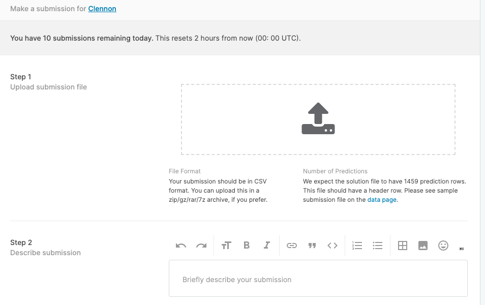

Now, I’ll put Ed’s code using data.table below so you can see how he did it using data.tables.

## Ed’s Beautiful Code using Data Tables

```r
# Setup ----------------------------------------------------------------------------------
  # Options
  options(stringsAsFactors = F)
  # Packages
  library(pacman)
  # devtools::install_github("tidymodels/parsnip")
  p_load(
    tidyverse, data.table, lubridate,
    ranger, parsnip,
    magrittr, here
  )

# Load data ------------------------------------------------------------------------------
  # Training data
  # you can use the 'here' function too that ed uses on his github - this is the fast and dirty approach.
  train_dt = '/Users/connor/Downloads/house-prices-advanced-regression-techniques/train.csv' %>% fread()
  # Testing data
  test_dt = "/Users/connor/Downloads/house-prices-advanced-regression-techniques/test.csv" %>% fread()

# Data work ------------------------------------------------------------------------------
  # Replace "NA" in alley with "No"
  train_dt[is.na(Alley), Alley := "No"]
  test_dt[is.na(Alley), Alley := "No"]
  # Same with fence
  train_dt[is.na(Fence), Fence := "No"]
  test_dt[is.na(Fence), Fence := "No"]
  # and MSZoning
  train_dt[is.na(MSZoning), MSZoning := "No"]
  test_dt[is.na(MSZoning), MSZoning := "No"]
  # and Utilities
  train_dt[is.na(Utilities), Utilities := "No"]
  test_dt[is.na(Utilities), Utilities := "No"]
  # and MiscFeature
  train_dt[is.na(MiscFeature), MiscFeature := "No"]
  test_dt[is.na(MiscFeature), MiscFeature := "No"]
  # and LotFrontage
  train_dt[is.na(LotFrontage), LotFrontage := 0]
  test_dt[is.na(LotFrontage), LotFrontage := 0]
  # and MasVnrArea
  train_dt[is.na(MasVnrArea), MasVnrArea := 0]
  test_dt[is.na(MasVnrArea), MasVnrArea := 0]
  # and MasVnrType
  train_dt[is.na(MasVnrType), MasVnrType := "None"]
  test_dt[is.na(MasVnrType), MasVnrType := "None"]
  # and SaleType
  train_dt[is.na(SaleType), SaleType := "?"]
  test_dt[is.na(SaleType), SaleType := "?"]
  # and Exterior1st
  train_dt[is.na(Exterior1st), Exterior1st := "?"]
  test_dt[is.na(Exterior1st), Exterior1st := "?"]
  # and Exterior2nd
  train_dt[is.na(Exterior2nd), Exterior2nd := "?"]
  test_dt[is.na(Exterior2nd), Exterior2nd := "?"]
  # and KitchenQual
  train_dt[is.na(KitchenQual), KitchenQual := "?"]
  test_dt[is.na(KitchenQual), KitchenQual := "?"]
  # Drop PoolQC
  train_dt[, PoolQC := NULL]
  test_dt[, PoolQC := NULL]
  # Drop FireplaceQu
  train_dt[, FireplaceQu := NULL]
  test_dt[, FireplaceQu := NULL]

# Train a model --------------------------------------------------------------------------
  # Train the model
  model_trained = rand_forest(mode = "regression", mtry = 12, trees = 10000) %>%
    set_engine("ranger", seed = 12345, num.threads = 10) %>%
    fit_xy(
      y = train_dt[,SalePrice],
      x = train_dt[,-c("Id", "SalePrice")] %>%
        select(MSSubClass:Foundation, KitchenQual, PoolArea:SaleCondition)
    )
  # Predict onto testing data
  new_predictions = predict(
    model_trained,
    new_data = test_dt
  )
  # Data to submit
# NOTE: Names and capitalization matter
  to_submit = data.frame(
    Id = test_dt$Id,
    SalePrice = new_predictions$.pred
  )
  # File to submit
  write_csv(
    x = to_submit,
    path = here("data", "to-submit-001.csv")
  )
```